# STAA57 Final Project Report

Team 10 (Daniela Venturo Esaine, Reizwan Chodhury, Ralph Samson Lal, Xiaotong Ye)

## Introduction

“Is university worth it?” is one of the hardest questions to answer. University is a very different experience from person to person depending on various factors. One of the main worries of most people is the heavy economical investment university takes. This skews the question towards the idea of measuring worth by future economical gain that cancels out the original investment. Therefore, to investigate if university is worth it, it makes sense to calculate the amount of time it takes to amortize total tuition cost in Canada.

Since tuition expenses show great variance depending on factors such as nationality, type of degree, or field of study, to have a relevant conclusion it is necessary to answer the following questions:

1. Is it worth it to get a Bachelor’s degree as a Canadian domestic student compared to an international student?
2. Is it worth it to get a Masters degree as a Canadian domestic student compared to an international student?
3. Is it worth it to get a masters degree immediately after getting a bachelors degree or is it better to invest in a masters degree after a few years?
4. What is the most “worth-it” field of study? (for undergraduate and graduate, for international and domestic)
5. What is the least “worth-it” field of study? (for undergraduate and graduate, for international and domestic)
6. Who has a bigger rate of unemployment? Bachelor degrees or master degrees?

## Data

The original sources for the data are: Tuition data: https://www.univcan.ca/universities/facts-and-stats/tuition-fees-by-university/ Provides graduate and undergraduate data for domestic and international students.

https://www150.statcan.gc.ca/n1/en/daily-quotidien/180905/dq180905b-eng.pdf?st=KKHzDvP6 Provides graduate and undergraduate data based on field of study.

Income data: http://sda.chass.utoronto.ca/sdaweb/html/lfs.htm http://sda.chass.utoronto.ca/sdaweb/tmpdir/AAkQ0GVH.txt <– codebook

#### Webscraping https://www.univcan.ca/universities/facts-and-stats/tuition-fees-by-university/

```r
URL = 'https://www.univcan.ca/universities/facts-and-stats/tuition-fees-by-university/'
page = read_html(url(URL))
univcan_data =
  page %>%
  html_nodes(xpath = '//*[@id="data_table"]') %>%
  html_table(fill = TRUE) %>%
  as.data.frame()
univcan_data = univcan_data[-1,]
univcan_data
```

|  | University | Undergraduate | Undergraduate.1 | Graduate | Graduate.1 | Province |
| --- | --- | --- | --- | --- | --- | --- |
| 2 | Memorial University of Newfoundland | $2,550 - $2,550 | $11,460 - $11,460 | $1,905 - $2,859 | $3,222 - $4,833 | Newfoundland & Labrador |
| 3 | University of Prince Edward Island | $6,150 - $6,150 | $13,326 - $13,326 | $4,134 - $5,000 * | $11,310 - $12,176 * | Prince Edward Island |
| 4 | Acadia University | $7,390 - $8,673 | $17,363 - $17,363 | $7,341 - $8,624 | $17,532 - $17,532 | Nova Scotia |
| 5 | Université Sainte-Anne | $6,277 - $7,560 | $10,340 - $10,340 | $6,277 - $7,560 * | $10,340 - $10,340 * | Nova Scotia |
| 6 | Dalhousie University | $6,355 - $7,638 | $17,148 - $17,148 | $6,805 - $8,088 | $17,598 - $17,598 | Nova Scotia |
| 7 | Mount Saint Vincent University | $6,418 - $7,701 | $15,402 - $15,402 | $5,020 - $5,789 | $10,410 - $10,410 | Nova Scotia |
| 8 | Nova Scotia College of Art and Design (NSCAD University) | $7,387 - $8,670 * | $19,170 - $19,170 * | $7,447 - $8,730 * | $19,350 - $19,350 * | Nova Scotia |
| 9 | St. Francis Xavier University | $7,287 - $8,570 | $17,140 - $17,140 | $4,730 - $5,500 | $11,000 - $11,000 | Nova Scotia |
| 10 | Saint Mary's University | $6,387 - $7,670 | $16,580 - $16,580 | $4,264 - $7,564 | $12,284 - $16,751 | Nova Scotia |
| 11 | University of King's College | $6,561 - $7,844 * | $17,354 - $17,354 * | $4,264 - $7,564 | $12,284 - $16,751 | Nova Scotia |

[output cut: 85 more lines]

#### Setting up the data in interest

```r
domestic_undergraduate =
  univcan_data %>%
  mutate(domestic_undergraduate_tuition = str_extract(Undergraduate, "(\\d+)[^-*]*$")) %>%
  select(University, domestic_undergraduate_tuition) %>% na.omit()
domestic_undergraduate$domestic_undergraduate_tuition =
  as.numeric(gsub(",","",domestic_undergraduate$domestic_undergraduate_tuition))
domestic_undergraduate
```

|  | University | domestic_undergraduate_tuition |
| --- | --- | --- |
| 1 | Memorial University of Newfoundland | 2550 |
| 2 | University of Prince Edward Island | 6150 |
| 3 | Acadia University | 8673 |
| 4 | Université Sainte-Anne | 7560 |
| 5 | Dalhousie University | 7638 |
| 6 | Mount Saint Vincent University | 7701 |
| 8 | St. Francis Xavier University | 8570 |
| 9 | Saint Mary's University | 7670 |
| 11 | Cape Breton University | 7800 |
| 12 | Mount Allison University | 8295 |

[output cut: 71 more lines]

```r
######################################################################################################################
international_undergraduate =
  univcan_data %>%
  mutate(international_undergraduate_tuition = str_extract(Undergraduate.1, "(\\d+)[^-*]*$")) %>%
  select(University, international_undergraduate_tuition) %>% na.omit()
international_undergraduate$international_undergraduate_tuition =
  as.numeric(gsub(",","", international_undergraduate$international_undergraduate_tuition))
international_undergraduate
```

|  | University | international_undergraduate_tuition |
| --- | --- | --- |
| 1 | Memorial University of Newfoundland | 11460 |
| 2 | University of Prince Edward Island | 13326 |
| 3 | Acadia University | 17363 |
| 4 | Université Sainte-Anne | 10340 |
| 5 | Dalhousie University | 17148 |
| 6 | Mount Saint Vincent University | 15402 |
| 8 | St. Francis Xavier University | 17140 |
| 9 | Saint Mary's University | 16580 |
| 11 | Cape Breton University | 15600 |
| 12 | Mount Allison University | 17600 |

[output cut: 70 more lines]

```r
######################################################################################################################
domestic_graduate =
  univcan_data %>%
  mutate(domestic_graduate_tuition = str_extract(Graduate, "(\\d+)[^-*]*$")) %>%
  select(University, domestic_graduate_tuition) %>% na.omit()
domestic_graduate$domestic_graduate_tuition =
  as.numeric(gsub(",", "", domestic_graduate$domestic_graduate_tuition))
domestic_graduate
```

|  | University | domestic_graduate_tuition |
| --- | --- | --- |
| 1 | Memorial University of Newfoundland | 2859 |
| 3 | Acadia University | 8624 |
| 5 | Dalhousie University | 8088 |
| 6 | Mount Saint Vincent University | 5789 |
| 8 | St. Francis Xavier University | 5500 |
| 9 | Saint Mary's University | 7564 |
| 10 | University of King's College | 7564 |
| 12 | Mount Allison University | 8295 |
| 13 | University of New Brunswick | 6843 |
| 14 | Université de Moncton | 7902 |

[output cut: 53 more lines]

```r
######################################################################################################################
international_graduate =
  univcan_data %>%
  mutate(international_graduate_tuition = str_extract(Graduate.1, "(\\d+)[^-*]*$")) %>%
  select(University, international_graduate_tuition) %>% na.omit()
international_graduate$international_graduate_tuition =
  as.numeric(gsub(",","", international_graduate$international_graduate_tuition))
international_graduate
```

|  | University | international_graduate_tuition |
| --- | --- | --- |
| 1 | Memorial University of Newfoundland | 4833 |
| 3 | Acadia University | 17532 |
| 5 | Dalhousie University | 17598 |
| 6 | Mount Saint Vincent University | 10410 |
| 8 | St. Francis Xavier University | 11000 |
| 9 | Saint Mary's University | 16751 |
| 10 | University of King's College | 16751 |
| 12 | Mount Allison University | 17600 |
| 13 | University of New Brunswick | 12144 |
| 14 | Université de Moncton | 14892 |

[output cut: 52 more lines]

#### Q1: Get a bachelor’s tuition (international vs. domestic)

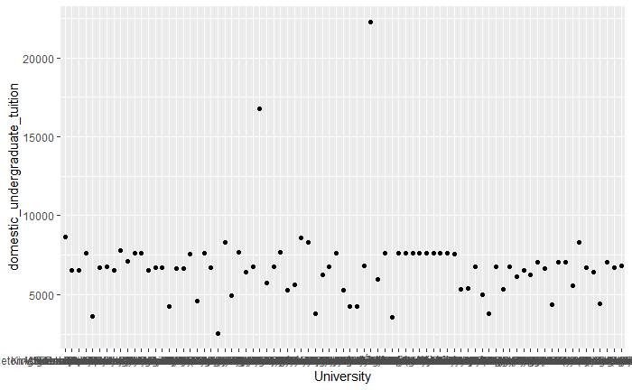

```r
domestic_undergraduate %>%
  arrange(domestic_undergraduate_tuition) %>%
  ggplot(aes(x=University, y = domestic_undergraduate_tuition)) + geom_point()
```

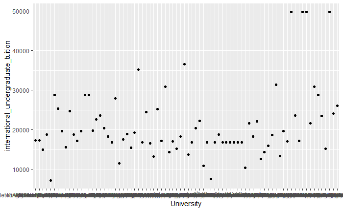

```r
international_undergraduate %>%
  arrange(international_undergraduate_tuition) %>%
  ggplot(aes(x=University, y = international_undergraduate_tuition)) + geom_point()
```

#### Shows Domestic vs. International (used LEFT JOIN)

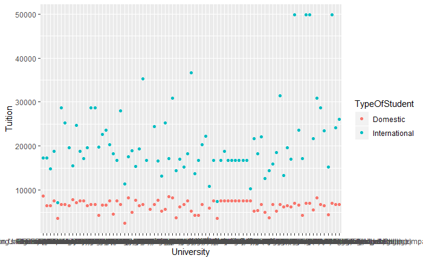

```r
domestic_international_undergraduate =
  left_join(domestic_undergraduate, international_undergraduate, by = "University")
domestic_international_undergraduate %>%
  ggplot(aes(x = University, y = Tuition, color = TypeOfStudent)) +
  geom_point(aes(y = domestic_undergraduate_tuition, col = "Domestic")) +
  geom_point(aes(y = international_undergraduate_tuition, col = "International"))
```

#### Q2: Get a masters (international vs. domestic)

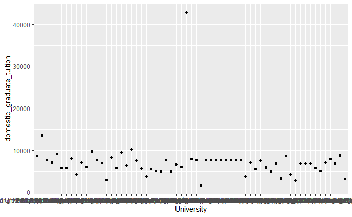

```r
domestic_graduate %>%
  arrange(domestic_graduate_tuition) %>%
  ggplot(aes(x=University, y = domestic_graduate_tuition)) + geom_point()
```

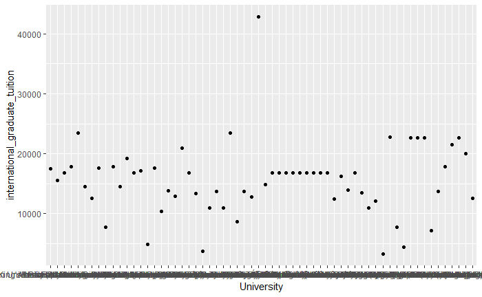

```r
international_graduate %>%
  arrange(international_graduate_tuition) %>%
  ggplot(aes(x=University, y = international_graduate_tuition)) + geom_point()
```

#### Shows Domestic vs. International (used LEFT JOIN)

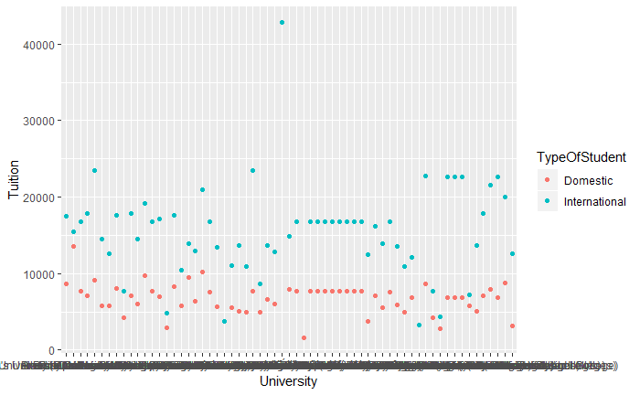

```r
domestic_international_graduate =
  left_join(domestic_graduate, international_graduate, by = "University")
domestic_international_graduate %>%
  ggplot(aes(x = University, y = Tuition, color = TypeOfStudent)) +
  geom_point(aes(y = domestic_graduate_tuition, col = "Domestic")) +
  geom_point(aes(y = international_graduate_tuition, col = "International"))
```

#### Q3: Get a masters immediately after a bachelor’s vs. after a few years

Assume there is four years of undergraduate study and 2 years of graduate study. The table shown below represents the total tuition fees for a domestic student and an international student have to pay if he/she is deciding to complete a master degree.

```r
domestic_sum = left_join(do, dog, by = "sum") %>% mutate(sum_tuition = 4*domestic_undergraduate_tuition + 2*domestic_graduate_tuition) %>% select(sum_tuition)
domestic_sum
```

| sum_tuition |
| --- |
| 15918 |
| 27448 |
| 26376 |
| 21778 |
| 21200 |
| 25328 |
| 25328 |
| 26790 |
| 23886 |
| 26004 |

[output cut: 990 more lines]

```r
international_sum = left_join(inter, interg, by = "sum") %>% mutate(sum_tuition = 4*international_undergraduate_tuition + 2*international_graduate_tuition) %>% select(sum_tuition)
international_sum
```

| sum_tuition |
| --- |
| 55506 |
| 80904 |
| 81036 |
| 66660 |
| 67840 |
| 79342 |
| 79342 |
| 81040 |
| 70128 |
| 75624 |

[output cut: 990 more lines]

```r
ngs = read.csv("../data/ngs.csv")
```

[output not shown]